# IODS course project

Eero Hippeläinen

# Introduction to Open Data Science - Course Project

# About the project

I’m very excited to attend a university course after many years. I have finished my Ph.D about 4 years ago. So I’m doing this course because I want to learn and update my skills.

I’m working as a medical physicist at the local university hospital. I carry out also some research projects. In the future, I’m hoping to do more teaching in HU.

This text was created on date: “13 December, 2021”

or using R chunk

```
## [1] "Mon Dec 13 01:23:30 2021"
```

and let see what happens next!

You can follow my project at github: [link to the project](https://github.com/Puolimatkassa/IODS-project.git)

# 2<sup>nd</sup> exercise: Data summary and regression analysis basics

The exercise consist 5 parts, which are separated in own sections (*below*). Data for the exercise was read from http://www.helsinki.fi/~kvehkala/JYTmooc/JYTOPKYS3-data.txt and it was processed (data wrangling) using a R script ([create_learning2014.R](https://github.com/Puolimatkassa/IODS-project/tree/master/scripts)). Data is stored into /data/learning2014.csv file. I won’t go into details about the data wrangling, so look at the file if interested.

Scripts can be found from my /scripts folder in IODS-project’s github repository.

### 1<sup>st</sup> part

First things first, so let’s read the data

```r
learning_data <- read.table("data/learning2014.csv",sep=",",header=T)
```

Data in this exercise is sample of bigger student questionnaire. It has 7 variables and 166 observations and the structure is following:

```r
str(learning_data)
```

```
## 'data.frame':    166 obs. of  7 variables:
##  $ gender  : chr  "F" "M" "F" "M" ...
##  $ Age     : int  53 55 49 53 49 38 50 37 37 42 ...
##  $ Attitude: int  37 31 25 35 37 38 35 29 38 21 ...
##  $ deep    : num  3.58 2.92 3.5 3.5 3.67 ...
##  $ stra    : num  3.38 2.75 3.62 3.12 3.62 ...
##  $ surf    : num  2.58 3.17 2.25 2.25 2.83 ...
##  $ Points  : int  25 12 24 10 22 21 21 31 24 26 ...
```

Questionnaire is about different kind of studying orientations. Orientation approaches were deep, surface (surf) and strategic (stra) approached orientations. In addition, gender, age, points and attitude were recorded from the students.

### 2<sup>nd</sup> part

In table (*below*), is summary of data. One third of students were male. The median age was 22, but having a some old students too.

| **Characteristic** | **N = 166**<sup>1</sup> |
| --- | --- |
| gender |  |
| F | 110 (66%) |
| M | 56 (34%) |
| Age | 22 (21, 27) |
| Attitude | 32 (26, 37) |
| deep | 3.67 (3.33, 4.08) |
| stra | 3.19 (2.62, 3.62) |
| surf | 2.83 (2.42, 3.17) |
| Points | 23 (19, 28) |

<sup>*1*</sup> n (%); Median (IQR)

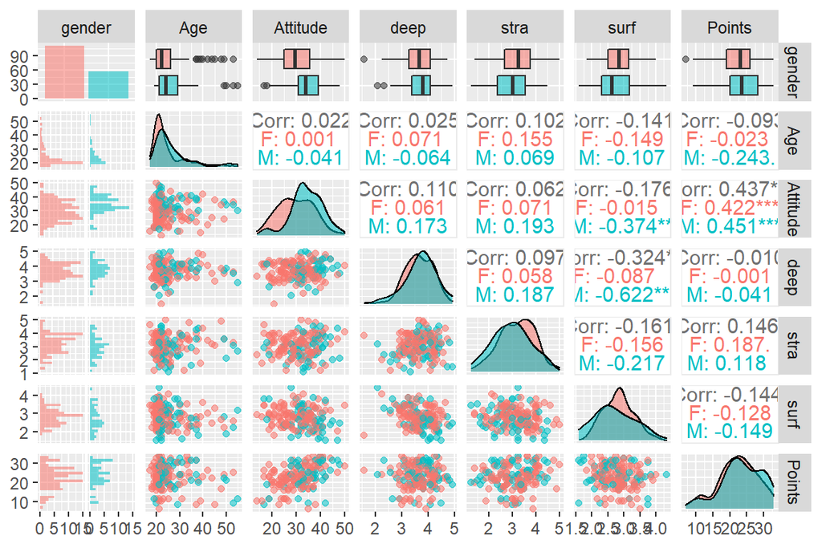

Summary of learning_data

### 3<sup>rd</sup> and 4<sup>th</sup> part

The rest of the analysis is done for whole dataset (female and male compined).

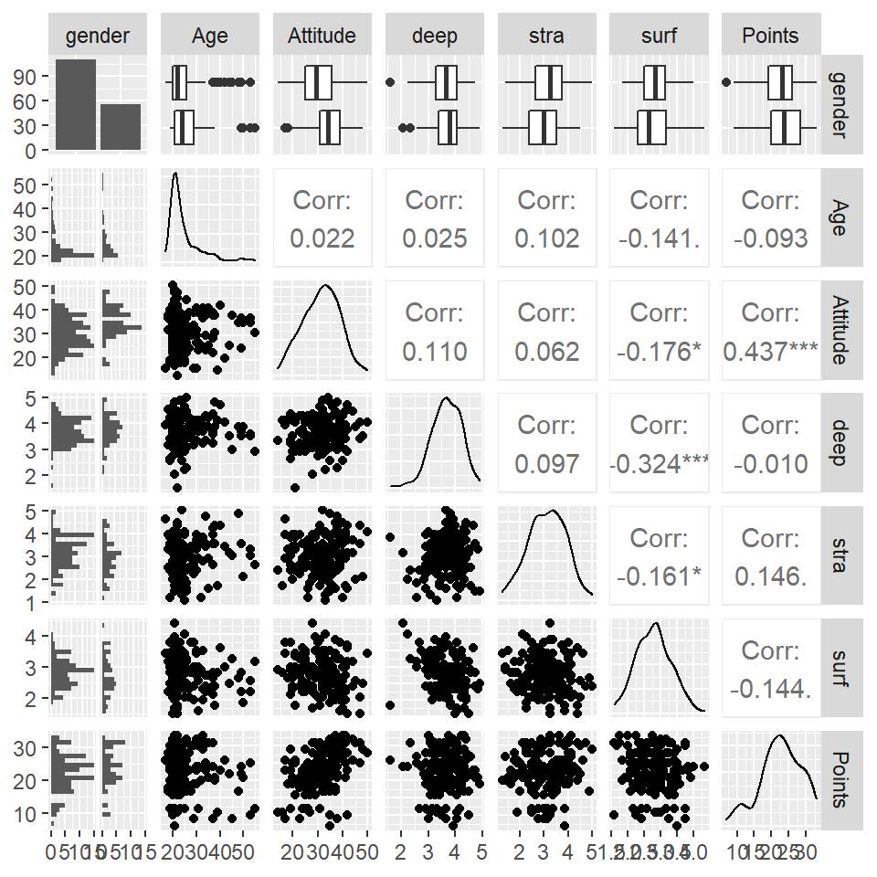

Summary of learning_data

Let assume that the total points gained can be ‘explained’ using three variables: attitude, age and strategic approach. Let’s assume that total points is linear combinations of those variables and errors are normally distributed, not correlated and have constant variance, $\sigma^2$. First, let’s plot each variable separately against the points.

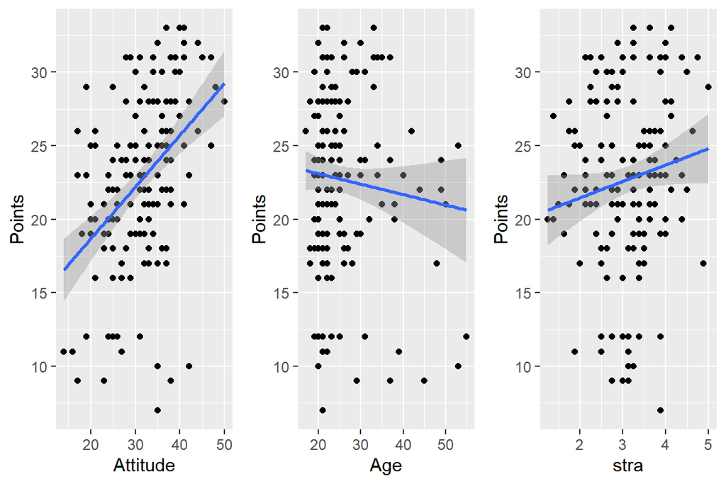

Next, let’s do a linear regression analysis to the data and see what it tells us.

```r
my_model1 <- lm(Points ~ Attitude + Age + stra, data = learning_data)
summary(my_model1)
```

```
##
## Call:
## lm(formula = Points ~ Attitude + Age + stra, data = learning_data)
##
## Residuals:
##      Min       1Q   Median       3Q      Max
## -18.1149  -3.2003   0.3303   3.4129  10.7599
##
## Coefficients:
##             Estimate Std. Error t value Pr(>|t|)
## (Intercept) 10.89543    2.64834   4.114 6.17e-05 ***
## Attitude     0.34808    0.05622   6.191 4.72e-09 ***
## Age         -0.08822    0.05302  -1.664   0.0981 .
## stra         1.00371    0.53434   1.878   0.0621 .
## ---
## Signif. codes:  0 '***' 0.001 '**' 0.01 '*' 0.05 '.' 0.1 ' ' 1
##
## Residual standard error: 5.26 on 162 degrees of freedom
## Multiple R-squared:  0.2182, Adjusted R-squared:  0.2037
## F-statistic: 15.07 on 3 and 162 DF,  p-value: 1.07e-08
```

It seems that student’s attitude is the best variable to forecasts student’s total points after one year. Interestingly, age seems to correlate negatively with the total points. Let’s remove age from our model and run the linear regression analysis again.

```r
my_model2 <- lm(Points ~ Attitude + stra, data = learning_data)
summary(my_model2)
```

```
##
## Call:
## lm(formula = Points ~ Attitude + stra, data = learning_data)
##
## Residuals:
##      Min       1Q   Median       3Q      Max
## -17.6436  -3.3113   0.5575   3.7928  10.9295
##
## Coefficients:
##             Estimate Std. Error t value Pr(>|t|)
## (Intercept)  8.97290    2.39591   3.745  0.00025 ***
## Attitude     0.34658    0.05652   6.132 6.31e-09 ***
## stra         0.91365    0.53447   1.709  0.08927 .
## ---
## Signif. codes:  0 '***' 0.001 '**' 0.01 '*' 0.05 '.' 0.1 ' ' 1
##
## Residual standard error: 5.289 on 163 degrees of freedom
## Multiple R-squared:  0.2048, Adjusted R-squared:  0.1951
## F-statistic: 20.99 on 2 and 163 DF,  p-value: 7.734e-09
```

Nothing special happens?! I’m getting bit tired and please let me know what I should have learned about this :D

### 5<sup>th</sup> part

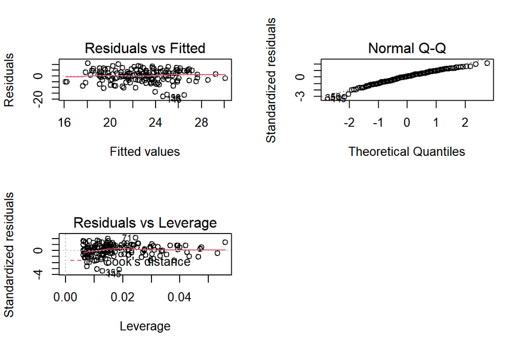

```r
par(mfrow=c(2,2))
plot(my_model2, which = c(1,2,5))
```

*interpretation*:

- From the Q-Q plot supports assumption that the errors of the model are normally distributed (or it was reasonable).
- Residual plot does not show any clear patterns, so I probably can assume that the errors have constant variance (more or less random scatter plot).
- It seems that no observations in our dataset that has high leverage on our fit.

# 3<sup>rd</sup> exercise: Data summary and predictin alcohol consumption

### 1<sup>st</sup> and 2<sup>nd</sup> part of the exercise

Data for the exercise was read from https://archive.ics.uci.edu/ml/datasets/Student+Performance and it was processed (data wrangling) using a R script ([create_alc.R](https://github.com/Puolimatkassa/IODS-project/tree/master/scripts)). Data is stored into /data/student_acl.csv file. I won’t go into details about the data wrangling, so look at the file if you are interested.

Data is very well described in the student.txt file which came with the data. Please refer to link to original data repository (*above*). Briefly, data is about secondary school’s student’ alcohol consumption. Data used in this exercise was combined from two different, but identical surveys which was given to math course and Portuguese course students. We are interested about alcohol users, who use regularly it. New variable, *high_use* was created and was *true* for those students who used alcohol more than two times per week, others was set *false*.

Scripts can be (again) found in my /scripts folder in IODS-project’s github repository.

First things first, so let’s read the data

```r
pormath2 <- read.table("data/student_alc.csv",sep=",",header=T)
```

### 3<sup>rd</sup> part

I believe that the three most important variables that promote to alcohol consumption are (variable names in parenthesis):

- if Sex = M (sex)
- parent’s cohabitation status = apart (Pstatus)
- and if quality of family relationships is low (1-2, where 5 is excellent) (famrel)

On the other hand, I believe that mother’s high education (Medu) will inhibit alcohol consumption. Let’s gather data what is needed:

Then have a look at the data and a quick view of correlations:

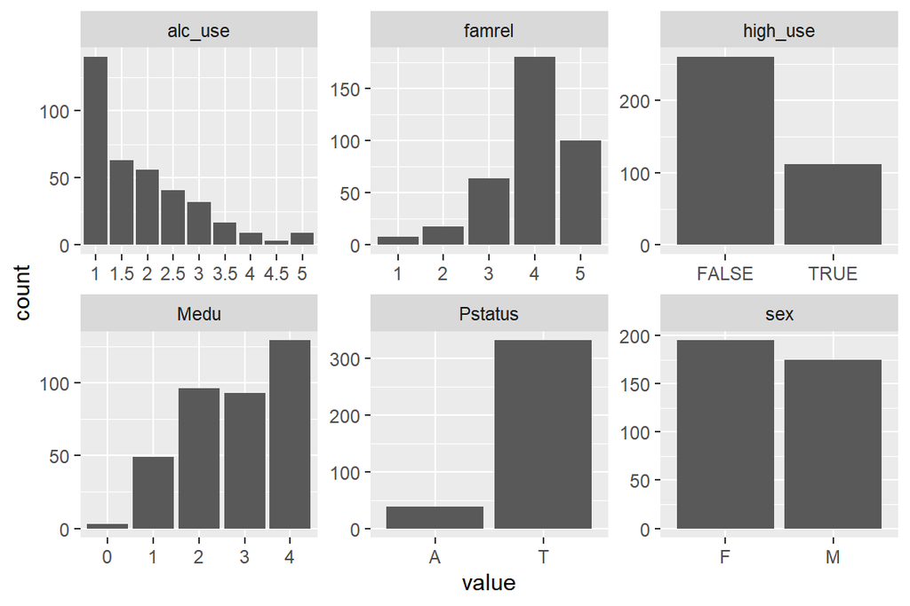

Summary of alcohol use among students

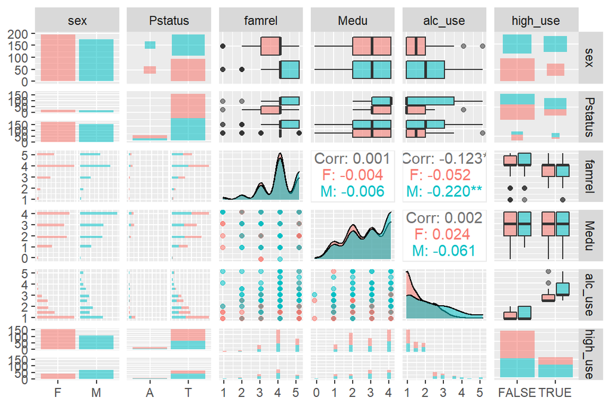

Summary of alcohol use among students

Let’s have a look at family relationships vs. high use box plot.

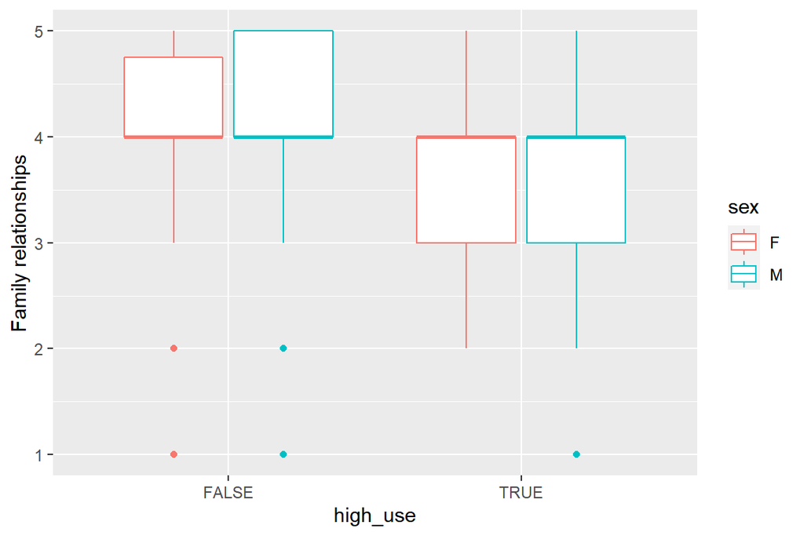

Family relationships vs. high alcohol use

It looks like that lower family relationship grade (1-5) have some prediction value for high alcohol use..

### Not enough time..

It seems that I’m not able to finish these exercise. Family and work duties… :( ***

# 4<sup>th</sup> exercise

Here I’m and it’s (again) 10pm on Sunday evening/night. Let’s get started! I have numbered the exercise sections to help you to follow my diary. Because you are reading this, I have maneged to done the first part of the exercise :)

### 2<sup>nd</sup> part

This time I’m analyzing data called *Boston* form the *Mass* library. It about housing values in suburbs of Boston. It includes lot of different kind of economical and social data about land usage, criminal rates, employment, and accessibility. More about the data set can be found ([here](https://stat.ethz.ch/R-manual/R-devel/library/MASS/html/Boston.html))

### 3<sup>rd</sup> part

I’ll use ggpairs to show overview of data:

[figure not shown]

Summary of Boston suburbs

It’s seems there are lot of correlations between variables, which implies that studied variables will separate suburbs from each other. For example: Median value of owner-occupied homes has inverse corralation with crimes. Distributions are (surprise) quite clustered. Correlation plot looks following:

```
##          crim    zn indus  chas   nox    rm   age   dis   rad   tax ptratio
## crim     1.00 -0.20  0.41 -0.06  0.42 -0.22  0.35 -0.38  0.63  0.58    0.29
## zn      -0.20  1.00 -0.53 -0.04 -0.52  0.31 -0.57  0.66 -0.31 -0.31   -0.39
## indus    0.41 -0.53  1.00  0.06  0.76 -0.39  0.64 -0.71  0.60  0.72    0.38
## chas    -0.06 -0.04  0.06  1.00  0.09  0.09  0.09 -0.10 -0.01 -0.04   -0.12
## nox      0.42 -0.52  0.76  0.09  1.00 -0.30  0.73 -0.77  0.61  0.67    0.19
## rm      -0.22  0.31 -0.39  0.09 -0.30  1.00 -0.24  0.21 -0.21 -0.29   -0.36
## age      0.35 -0.57  0.64  0.09  0.73 -0.24  1.00 -0.75  0.46  0.51    0.26
## dis     -0.38  0.66 -0.71 -0.10 -0.77  0.21 -0.75  1.00 -0.49 -0.53   -0.23
## rad      0.63 -0.31  0.60 -0.01  0.61 -0.21  0.46 -0.49  1.00  0.91    0.46
## tax      0.58 -0.31  0.72 -0.04  0.67 -0.29  0.51 -0.53  0.91  1.00    0.46
## ptratio  0.29 -0.39  0.38 -0.12  0.19 -0.36  0.26 -0.23  0.46  0.46    1.00
## black   -0.39  0.18 -0.36  0.05 -0.38  0.13 -0.27  0.29 -0.44 -0.44   -0.18
## lstat    0.46 -0.41  0.60 -0.05  0.59 -0.61  0.60 -0.50  0.49  0.54    0.37
## medv    -0.39  0.36 -0.48  0.18 -0.43  0.70 -0.38  0.25 -0.38 -0.47   -0.51
##         black lstat  medv
## crim    -0.39  0.46 -0.39
## zn       0.18 -0.41  0.36
## indus   -0.36  0.60 -0.48
## chas     0.05 -0.05  0.18
## nox     -0.38  0.59 -0.43
## rm       0.13 -0.61  0.70
## age     -0.27  0.60 -0.38
## dis      0.29 -0.50  0.25
## rad     -0.44  0.49 -0.38
## tax     -0.44  0.54 -0.47
## ptratio -0.18  0.37 -0.51
## black    1.00 -0.37  0.33
## lstat   -0.37  1.00 -0.74
## medv     0.33 -0.74  1.00
```

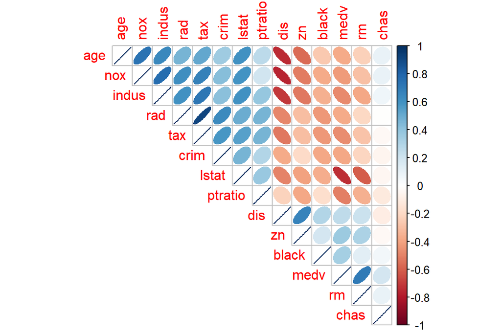

Correlation plot of Boston dataset

It seems that there are some very intuitive correlations:

- like accessibility to radial highways (*rad*) correlates positively with ull-value property-tax rate (*tax*)
- Lower status (lower education of adults, *lstat*) has a negative correlations with number of rooms in dwelling/flat (*rm*)

### 4<sup>th</sup> part

Scaling can be done easily with *scale* function. It will calculate difference of variable value and the mean, and then divided by standard deviation of the variable: $scaled(x)=\frac{x-\bar{x}}{sd(x)}$

What *scale* function does: Variable’s values are scattered around the mean, *scale* function shifts data around zero and the distance from the mean/zero is scaled with standard deviation. This is seems very logical way to scale. After the scale, mean of the all data will be 0 and 1 standard deviation will be 1 :D.

I’m bit worried about this, because distributions did not look normally distributed. *Scale* function will change the distributions and I’m curious if someone could tell me more about this..

In this case, all variables are numerical so no additional parameters needed for *scale* function call:

```r
boston_scaled <- scale(Boston)
summary(boston_scaled)
```

```
##       crim                 zn               indus              chas
##  Min.   :-0.419367   Min.   :-0.48724   Min.   :-1.5563   Min.   :-0.2723
##  1st Qu.:-0.410563   1st Qu.:-0.48724   1st Qu.:-0.8668   1st Qu.:-0.2723
##  Median :-0.390280   Median :-0.48724   Median :-0.2109   Median :-0.2723
##  Mean   : 0.000000   Mean   : 0.00000   Mean   : 0.0000   Mean   : 0.0000
##  3rd Qu.: 0.007389   3rd Qu.: 0.04872   3rd Qu.: 1.0150   3rd Qu.:-0.2723
##  Max.   : 9.924110   Max.   : 3.80047   Max.   : 2.4202   Max.   : 3.6648
##       nox                rm               age               dis
##  Min.   :-1.4644   Min.   :-3.8764   Min.   :-2.3331   Min.   :-1.2658
##  1st Qu.:-0.9121   1st Qu.:-0.5681   1st Qu.:-0.8366   1st Qu.:-0.8049
##  Median :-0.1441   Median :-0.1084   Median : 0.3171   Median :-0.2790
##  Mean   : 0.0000   Mean   : 0.0000   Mean   : 0.0000   Mean   : 0.0000
##  3rd Qu.: 0.5981   3rd Qu.: 0.4823   3rd Qu.: 0.9059   3rd Qu.: 0.6617
##  Max.   : 2.7296   Max.   : 3.5515   Max.   : 1.1164   Max.   : 3.9566
##       rad               tax             ptratio            black
##  Min.   :-0.9819   Min.   :-1.3127   Min.   :-2.7047   Min.   :-3.9033
##  1st Qu.:-0.6373   1st Qu.:-0.7668   1st Qu.:-0.4876   1st Qu.: 0.2049
##  Median :-0.5225   Median :-0.4642   Median : 0.2746   Median : 0.3808
##  Mean   : 0.0000   Mean   : 0.0000   Mean   : 0.0000   Mean   : 0.0000
##  3rd Qu.: 1.6596   3rd Qu.: 1.5294   3rd Qu.: 0.8058   3rd Qu.: 0.4332
##  Max.   : 1.6596   Max.   : 1.7964   Max.   : 1.6372   Max.   : 0.4406
##      lstat              medv
##  Min.   :-1.5296   Min.   :-1.9063
##  1st Qu.:-0.7986   1st Qu.:-0.5989
##  Median :-0.1811   Median :-0.1449
##  Mean   : 0.0000   Mean   : 0.0000
##  3rd Qu.: 0.6024   3rd Qu.: 0.2683
##  Max.   : 3.5453   Max.   : 2.9865
```

```r
boston_scaled <- as.data.frame(boston_scaled)
```

Then I’ll follow strickly the datacamp example, because I don’t have much imagination to improvise about this part. Following steps are mechanical and no words needed. First *crime* variable is “split” by it’s quantiles (= it’s divided into equal-size, adjacent, subgroups). Then quantiles are named and old variable *crim* is replaced by categorized variable *crime*:

```r
summary(boston_scaled$crim)
```

```
##      Min.   1st Qu.    Median      Mean   3rd Qu.      Max.
## -0.419367 -0.410563 -0.390280  0.000000  0.007389  9.924110
```

```r
bins <- quantile(boston_scaled$crim)
bins
```

```
##           0%          25%          50%          75%         100%
## -0.419366929 -0.410563278 -0.390280295  0.007389247  9.924109610
```

```r
crime <- cut(boston_scaled$crim, breaks = bins, include.lowest = TRUE, labels = c("low", "med_low", "med_high", "high"))
table(crime)
```

```
## crime
##      low  med_low med_high     high
##      127      126      126      127
```

```r
boston_scaled <- dplyr::select(boston_scaled, -crim)
boston_scaled <- data.frame(boston_scaled, crime)
```

Next, 80 percent of data will be training data and the rest will be test data.

```r
n <- nrow(boston_scaled)
ind <- sample(n,  size = n * 0.8)
train <- boston_scaled[ind,]
test <- boston_scaled[-ind,]
correct_classes <- test$crime
```

### 5<sup>th</sup> part

```r
lda.fit <- lda(crime ~ ., data = train)

# print the lda.fit object
lda.fit
```

```
## Call:
## lda(crime ~ ., data = train)
##
## Prior probabilities of groups:
##       low   med_low  med_high      high
## 0.2648515 0.2500000 0.2475248 0.2376238
##
## Group means:
##                  zn      indus          chas        nox          rm        age
## low       0.9072686 -0.9343206 -0.1619430798 -0.8794055  0.41684100 -0.8502243
## med_low  -0.1696947 -0.3128532  0.0005392655 -0.5718134 -0.09338597 -0.3005468
## med_high -0.3826200  0.1904452  0.2394939629  0.3977897  0.17852626  0.4205889
## high     -0.4872402  1.0172418 -0.1903061461  1.0365883 -0.39803418  0.7878166
##                 dis        rad        tax    ptratio      black        lstat
## low       0.8967518 -0.6985111 -0.7460780 -0.4102846  0.3800347 -0.767429253
## med_low   0.2650139 -0.5634198 -0.4876531 -0.0517192  0.3243676 -0.166100312
## med_high -0.4044126 -0.4225678 -0.3116059 -0.3295850  0.1241896 -0.005526243
## high     -0.8508219  1.6368728  1.5131579  0.7793151 -0.9161793  0.945698467
##                 medv
## low       0.49161119
## med_low   0.02603764
## med_high  0.23324665
## high     -0.74043847
##
## Coefficients of linear discriminants:
##                  LD1          LD2        LD3
## zn       0.089504756  0.634779296 -0.8801887
## indus    0.096507381 -0.332162804  0.1767418
## chas    -0.114297880 -0.181178921  0.1079985
## nox      0.395265839 -0.678249198 -1.5240309
## rm      -0.106962924 -0.146929365 -0.1850395
## age      0.139865056 -0.246642123 -0.1446161
## dis     -0.054269743 -0.166845261 -0.1901565
## rad      3.377573242  0.996795921 -0.1625930
## tax      0.008502548 -0.103491801  0.6549714
## ptratio  0.089903954  0.035940625 -0.2842986
## black   -0.148058678 -0.006861372  0.1151717
## lstat    0.240865972 -0.272758196  0.3147951
## medv     0.199573893 -0.378614936 -0.2676724
##
## Proportion of trace:
##    LD1    LD2    LD3
## 0.9496 0.0375 0.0129
```

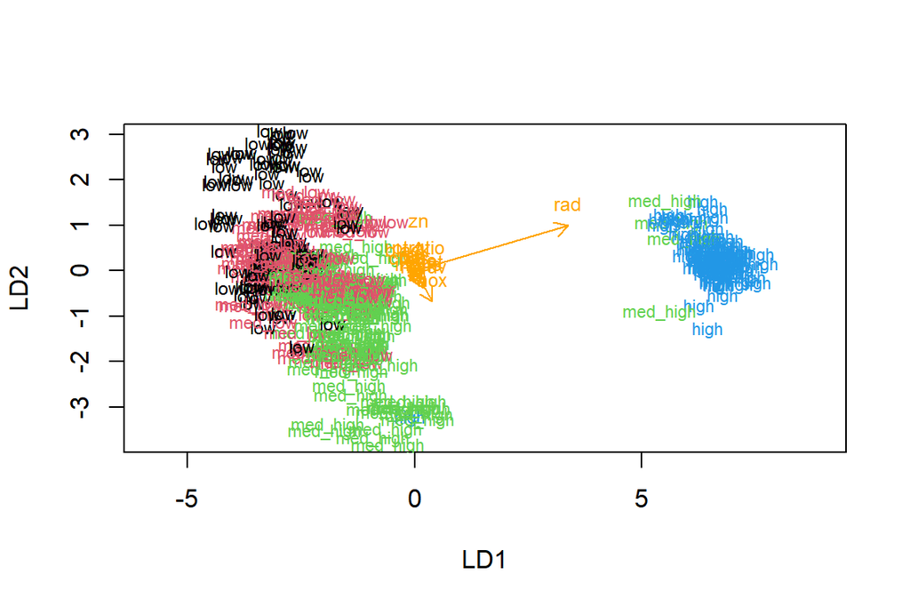

```r
lda.arrows <- function(x, myscale = 1, arrow_heads = 0.1, color = "orange", tex = 0.75, choices = c(1,2)){
  heads <- coef(x)
  arrows(x0 = 0, y0 = 0,
         x1 = myscale * heads[,choices[1]],
         y1 = myscale * heads[,choices[2]], col=color, length = arrow_heads)
  text(myscale * heads[,choices], labels = row.names(heads),
       cex = tex, col=color, pos=3)
}

# target classes as numeric
classes <- as.numeric(train$crime)

# plot the lda results
plot(lda.fit, dimen = 2, col = classes, pch = classes)
lda.arrows(lda.fit, myscale = 1)
```

### 6<sup>th</sup> part

```r
test <- dplyr::select(test, -crime)
# predict classes with test data
lda.pred <- predict(lda.fit, newdata = test)

# cross tabulate the results


table(correct = correct_classes, predicted = lda.pred$class)
```

```
##           predicted
## correct    low med_low med_high high
##   low       14       6        0    0
##   med_low    9      12        4    0
##   med_high   1      10       13    2
##   high       0       0        0   31
```

### 7^th part

```r
data("Boston")
scaled2<-scale(Boston)

dist_eu <- dist(scaled2)

# look at the summary of the distances
summary(dist_eu)
```

```
##    Min. 1st Qu.  Median    Mean 3rd Qu.    Max.
##  0.1343  3.4625  4.8241  4.9111  6.1863 14.3970
```

```r
# manhattan distance matrix
dist_man <- dist(scaled2, method = 'manhattan')

summary(dist_man)
```

```
##    Min. 1st Qu.  Median    Mean 3rd Qu.    Max.
##  0.2662  8.4832 12.6090 13.5488 17.7568 48.8618
```

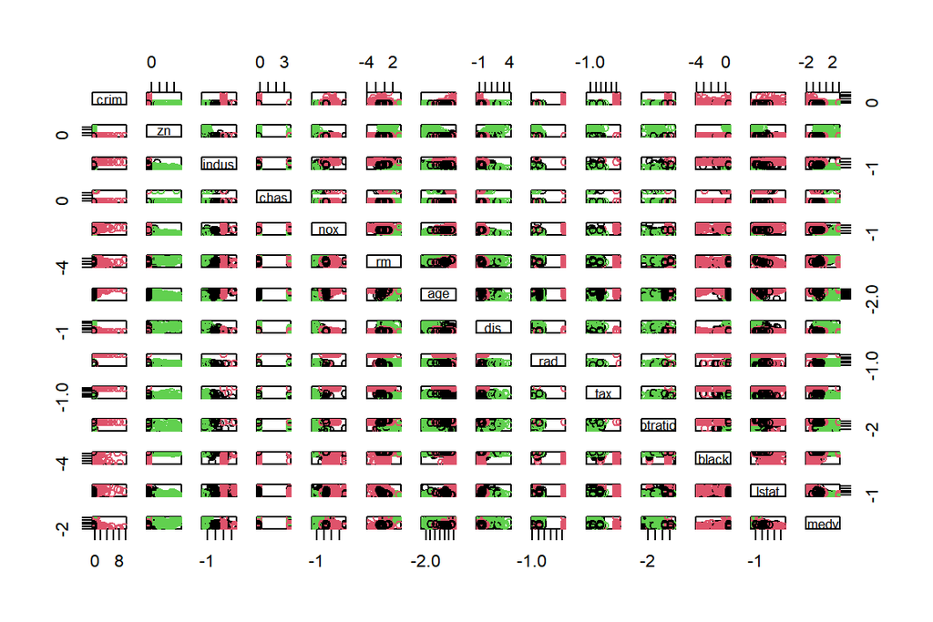

```r
# k-means clustering
km <-kmeans(scaled2, centers = 3)

scaled2 <- as.data.frame(scaled2)

# plot the Boston data set with clusters
pairs(scaled2, col = km$cluster)
```

It look bit wierd. Let’s see can we use more clusters to get better fit.

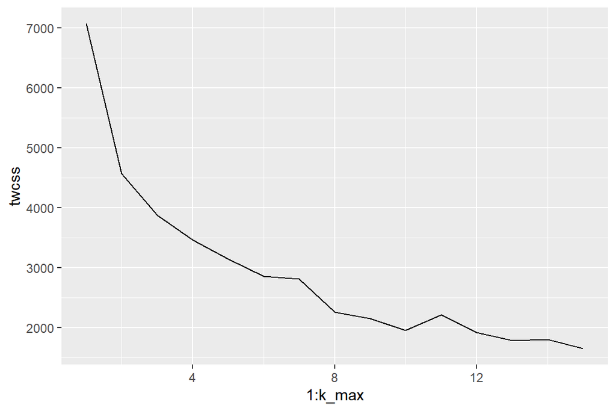

```r
set.seed(123)

k_max <- 15

# calculate the total within sum of squares
twcss <- sapply(1:k_max, function(k){kmeans(scaled2, k)$tot.withinss})

# visualize the results
qplot(x = 1:k_max, y = twcss, geom = 'line')
```

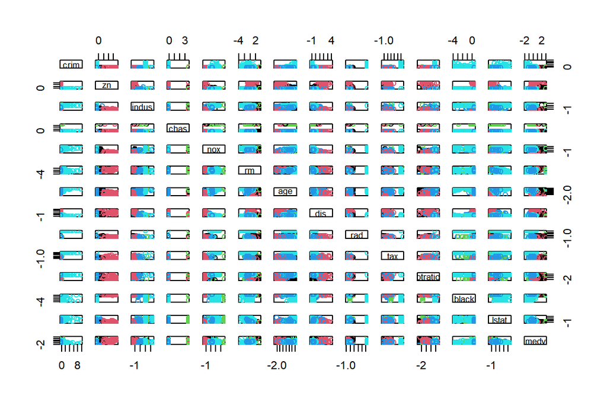

```r
# k-means clustering
km <-kmeans(scaled2, centers = 5)

# plot the Boston dataset with clusters
pairs(scaled2, col = km$cluster)
```

Well, it’s 01:00 am and time to go sleep!

# I did not start or finish the 5<sup>th</sup> exercise.

# 6<sup>th</sup> exercise: Rat weigth treatment comparison and Psyciatric longitudial data

In this exercise I’ll run two analysis from Kimmo Vehkalati’s book. I’ll start with the RATSL data, and run Chapter 8 analysis for it (data is swapped). RATSL was created with the R script (data wrangling) ([meet_and_repeat.R](https://github.com/Puolimatkassa/IODS-project/tree/master/scripts)). And yes, I like to put scripts to separate folder.

I won’t go into details about the data wrangling, so look at the file if interested.

### Rat’s getting some weight treatment :)

I’ll load some libraries first, and will put more here, what ever I’ll need.

```r
library(ggplot2)
library(GGally)
library(gtsummary)
library(dplyr)
library(tidyr)
```

First load the RATSL data:

```r
RATS <- read.table("data/RATS.csv",sep=",",header=T)
RATS$ID <- factor(RATS$ID)
RATS$Group <- factor(RATS$Group)

RATSL <- RATS %>%
  gather(key = WD, value = Weight, -ID, -Group) %>%
  mutate(Time = as.integer(substr(WD,3,4)))
```

There are 8 rats in group 1 and 4 rats in groups 2,3.

```r
table(RATS$Group)
```

```
##
## 1 2 3
## 8 4 4
```

Let’s plot weights as function of time in their groups.

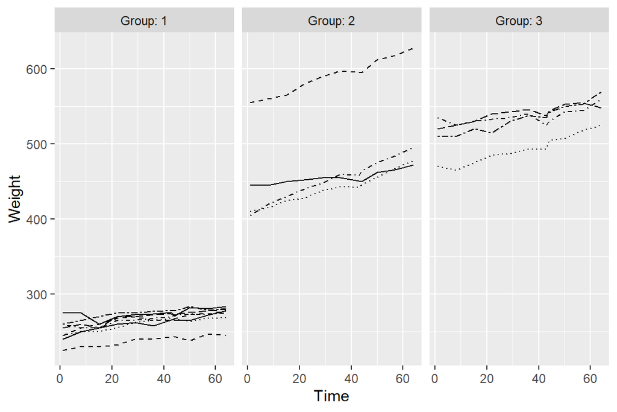

As we can see, that groups start at different average weights. This means that the change in weight over time is “harder” to compare between groups. To get data more comparable, I’ll scale weights:

```r
RATSL <- RATSL %>%
  group_by(Group,Time) %>%
  mutate(stdweight = ((Weight-mean(Weight))/sd(Weight))) %>%
  ungroup()
```

Let’s plot the scaled (standardized) data:

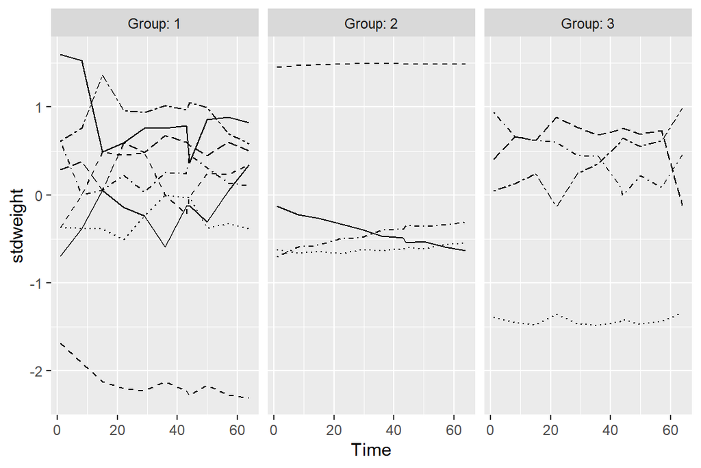

Well, it did not help much. Then let’s look at the group averages over experiment:

```r
n <- RATSL$Time %>% unique() %>% length()

RATSS <- RATSL %>%
  group_by(Group, Time) %>%
  summarise( mean = mean(Weight), se = sd(Weight)/sqrt(n) ) %>%
  ungroup()
glimpse(RATSS)
```

```
## Rows: 33
## Columns: 4
## $ Group <fct> 1, 1, 1, 1, 1, 1, 1, 1, 1, 1, 1, 2, 2, 2, 2, 2, 2, 2, 2, 2, 2, 2~
## $ Time  <int> 1, 8, 15, 22, 29, 36, 43, 44, 50, 57, 64, 1, 8, 15, 22, 29, 36, ~
## $ mean  <dbl> 250.625, 255.000, 254.375, 261.875, 264.625, 265.000, 267.375, 2~
## $ se    <dbl> 4.589478, 3.947710, 3.460116, 4.100800, 3.333956, 3.552939, 3.30~
```

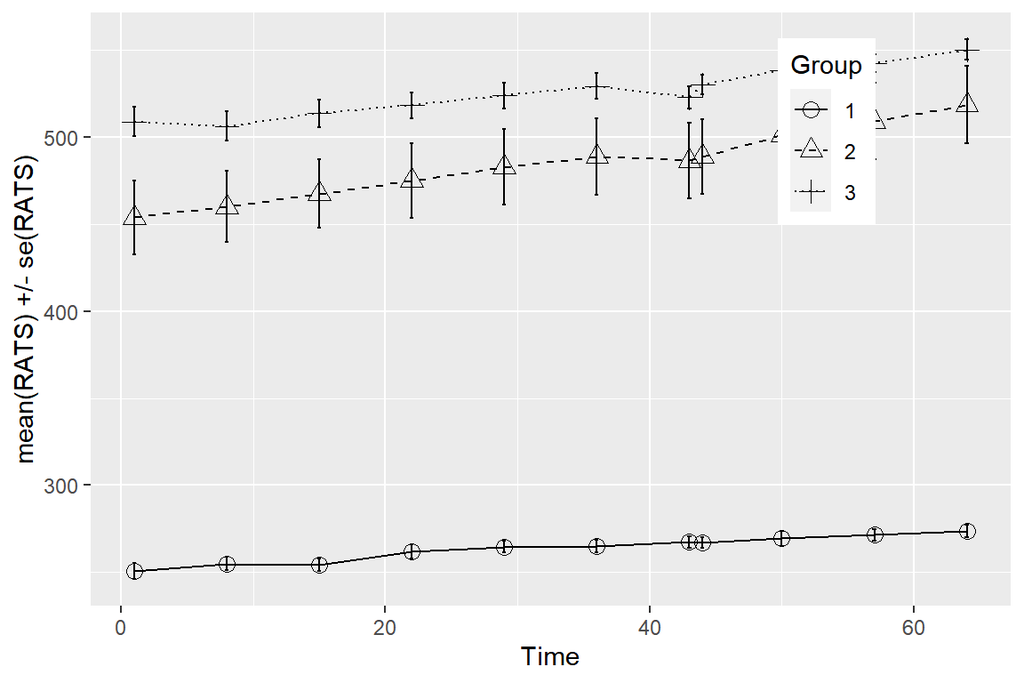

Still it’s hard to say, which group of rats gained more weight. Next, I’ll calculate difference of start weight and the weight at the end:

```r
rateofchange <- RATSL %>%
  group_by(Group,ID) %>%
  summarise(diff = last(Weight) - first(Weight), increase = diff /first(Weight)) %>%
  arrange(increase)
```

And then prepare data for boxplot over the three groups.

```r
RATSDIFF <- rateofchange %>%
  summarise( mean=mean(increase) ) %>%
  ungroup()
```

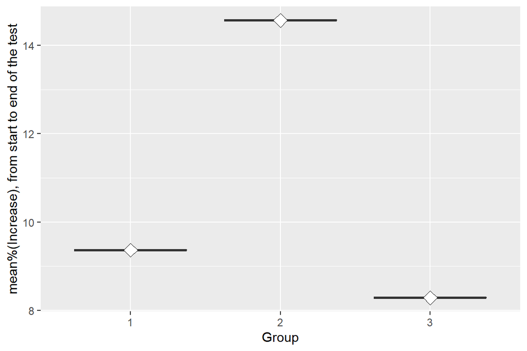

From the graph above, we can see that the biggest gain on weight was found on the group 2, gaining about almost 15% weight.

It’s already 01:13 and I have a work day tomorrow. Hopefully this was one way to do it! No energy left for the Second part of the exercise..